# Databases: Instructor Joan Ngugi

## Objective

### By the end of this module we will have learnt the below key concepts:

- Database creation
- Tables
- Adding data to your database
- Querying a database
- Relational database design

## Introduction

- Throughout history, humans have tried to store information in one form or another.
- The Egyptians inscribed hieroglyphs on tomb walls, papyrus, and wood as long ago as 3200 B.C. to preserve their message for posterity. In recent centuries, paper has been used as a medium to store information.
- Fast forward to the 20th century, electronic storage and retrieval of information have become commonplace.

[figure not shown]

## Data

- Data is defined as distinct pieces of information.

#### Three categories of data:

- Structured Data - Structured data is a standardized format for providing information about a page and classifying that content on the page. Structured data is typically stored in a relational database (RDBMS). It can consist of numbers and text.
- Unstructured Data - Unstructured data is information that is not arranged according to a pre-set data model or schema, and therefore cannot be stored in a traditional relational database or RDBMS. ex videos, audio.
- Semi-structured Data -is a cross between structured and unstructured data

## Database Definition

- A database is an organized and structured collection of data, usually stored and retrieved electronically. ### There are broadly two types of databases:
1. Relational or SQL Databases
2. Non-Relational or NoSQL Databases

In this module, our focus will be on relational databases.

## Methods of Saving Data?

- TextFile

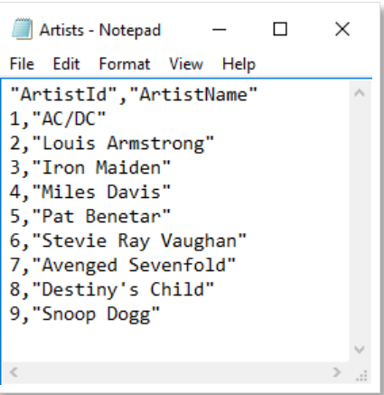

- Spreadsheet

[figure not shown]

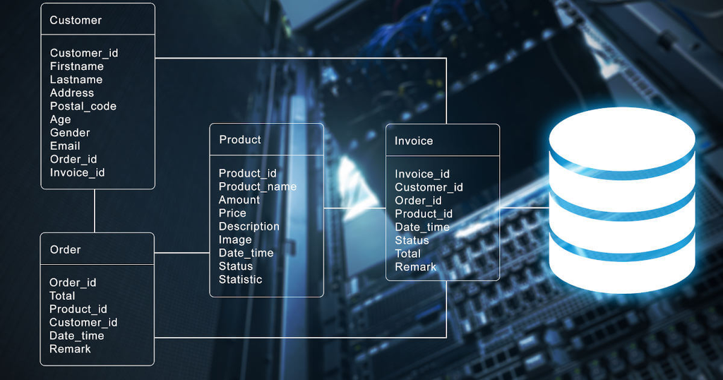

Every table is broken up into smaller entities called fields. The fields in the Customers table consist of CustomerID, FirstName, LastName etc. A field is a column in a table that is designed to maintain specific information about every record in the table.

A record, also called a row, is each individual entry that exists in a table.A record is a horizontal entity in a table.

A column is a vertical entity in a table that contains all information associated with a specific field in a table.

## Database Management Systems

- A Database Management System (DBMS), is a software program that enables the creation and management of databases.
- Most of today's database systems are referred to as a Relational Database Management System (RDBMS), because of their ability to store related data across multiple tables.

Examples:

- Microsoft Access
- MySQL
- Oracle
- SQL Server
- SQLite
- PostgreSQL

Some database management systems include a graphical user interface that allows you to create and maintain databases by "pointing and clicking".

Other database systems use a command line interface that requires that you use certain programming commands to create and maintain your databases.

But most command line database systems also provide the option of installing graphical admin tools that allow you to "point and click" your way through most tasks.

# SQL

- SQL is a standard language for accessing and manipulating databases.
- SQL is the most common language for extracting and organising data that is stored in a relational database.
- A database is a table that consists of rows and columns. SQL is the language of databases.

### What SQL can do

SQL can retrieve data from a database

SQL can insert records in a database

SQL can update records in a database

SQL can delete records from a database

SQL can create new databases

SQL can create new tables in a database

SQL can create stored procedures in a database

SQL can create views in a database

SQL can set permissions on tables, procedures, and views

## Creating a Database

- Syntax

CREATE DATABASE testDB;

# Creating a Table

- A database consists of one or more tables.
- Each table is made up of rows and columns.

## Syntax

CREATE TABLE table_name (

```
column1 datatype,

column2 datatype,

column3 datatype,
```

);

Example

CREATE TABLE ClassList

(

FirstName Varchar(255),

LastName Varchar(255),

);

# Insert Into

- The INSERT INTO statement is used to insert new records in a table.

### INSERT SYNTAX

INSERT INTO table_name (column1, column2, column3, ...)

VALUES (value1, value2, value3, ...);

Example

Option 1:

INSERT INTO CLassList (FirstName)

VALUES ('Racheal'),('Joan'),('Ngugi');

Example

Option 2:

INSERT INTO CLassList (FirstName, LastName) VALUES ('Racheal','Green');

Example

Option 3:

INSERT INTO CLassList VALUES ('Chandler ','Bing'),('Monicah','Geller'), ('Phoebe','Buffay')

## Question

- Add 3 people in the class into database ClassList

# SQL Select

- The SELECT statement is used to select data from a database.

### SELECT Syntax

#### Specifying Fields

SELECT column1, column2, FROM table_name;

Example : SELECT FirstName, LastName FROM EMPLOYEES

```python
#### Selecting all Fields

SELECT * FROM table_name;
SELECT * FROM EMPLOYEES;
```

```python
## Question
- Select every record from the genres table
```

## SQL WHERE

- You can use the WHERE clause to narrow the results down. The clause allows you to stipulate specific criteria for which to apply to the query.
- SQL requires single quotes around text values.numeric fields should not be enclosed in quotes:

### WHERE SYNTAX

SELECT column1, column2,

FROM table_name

WHERE condition;

Operators

- = Equal
- > Greater than
- < Less than
- > = Greater than or equal
- <= Less than or equal
- <> Not equal. Note: In some versions of SQL this operator may be written as !=
- BETWEEN Between a certain range
- LIKE Search for a pattern
- IN To specify multiple possible values for a column
- NOT reverses the value of other operators such as NOT EXISTS, NOT IN, NOT BETWEEN, etc.

## Example (Equal =)

SELECT FIRSTNAME,LASTNAME

FROM customers

WHERE country='Brazil'

### Questions

- Provide a query showing Customers (just their full names, customer ID and country) who are not in the US.
- Provide a query showing all customer records whose CustomerID column has the value 32.
- Provide a query showing all invoices whose total amount is greater than 10 dollars

# SQL NOT

- The NOT operator displays a record if the condition(s) is NOT TRUE.

## Example 1 (NOT)

SELECT customerid, firstname, lastname, country

FROM customers

WHERE not country = 'USA'

### Example 2 (NOT)

SELECT customerid, firstname, lastname, country FROM customers WHERE country != 'Brazil';

# SQL AND

- The AND operator displays a record if all the conditions separated by AND are TRUE.

#### Example 1(AND) The following SQL statement selects all fields from "Customers" where country is "France" AND city is "Paris":

SELECT * FROM Customers

WHERE Country='France' AND City='Paris';

# SQL OR

- The OR operator displays a record if any of the conditions separated by OR is TRUE.

#### The following SQL statement selects all fields from "Customers" where city is "London" OR "Paris":

SELECT * FROM Customers WHERE City='London' OR City='Paris';

# SQL ORDER BY

- Used to sort the result-set in ascending or descending order.
- ORDER BY sorts the records in ascending order by default. To sort the records in descending order, use the DESC keyword.

## Order By Syntax

SELECT column1, column2

FROM table_name

ORDER BY column1, column2, ... ASC|DESC;

#### Example 1 (Order By)

SELECT * FROM Customers

ORDER BY City;

#### Example 2 (Order By)

SELECT * FROM Customers

ORDER BY City DESC;

#### Example 3 (Order By)

SELECT * FROM Customers

ORDER BY Country DESC, FirstName ASC;

# SQL LIMIT

- LIMIT clause constrainS the number of rows returned by a query.

## LIMIT SYNTAX

SELECT column1, column2,

FROM table_name

LIMIT ROW COUNT;

#### Example 1 (LIMIT)

SELECT * FROM invoices limit 10

```python
## Select Billing Country InvoiceId, Invoice date, order by Billing Country---LIMIT 20 (Table name invoices)
```

# SQL UPDATE

-The UPDATE query is used to modify the existing records in a table.

#### Example 1 (Update) - One Column

UPDATE employees

SET Title = 'IT ADMIN'

WHERE employeeid = 8;

UPDATE employees

SET Title='SSA'

WHERE Title='Sales Support Agent';

UPDATE Customers

SET POSTALCODE=213

WHERE Country='Brazil';

# SQL LIKE

- The LIKE operator is used in a WHERE clause to search for a specified pattern in a column.
- Note that you can also use the LIKE operator in the WHERE clause of other statements such as the DELETE and UPDATE

## LIKE SYNTAX

SELECT column1, column2,

FROM table_name

WHERE columnN LIKE pattern;

```python
## Table Customers retrieve CustomerID, CustomerName, Phone ----> +55 using LIKE
```

### Example 1 (LIKE)

SELECT composer,name

FROM tracks

WHERE name LIKE '%Wild%';

#### Example 2 (LIKE) The following SQL statement selects all customers with a FirstName starting with "a":

SELECT * FROM Customers

WHERE CustomerName LIKE 'a%';

#### Example 3 (LIKE) The following SQL statement selects all customers with a FirstName ending with "a":

SELECT * FROM Customers

WHERE CustomerName LIKE '%a';

#### Example 4 (LIKE) The following SQL statement selects all customers whose country code has "+44" in any position

SELECT * FROM Customers

WHERE PHONE LIKE '%+44%'

# Connecting to a database from NOTEBOOK

```python
#!pip install mysql-connector-python
```

```python
import pandas as pd
```

```python
mysql_driver='mysql+pymysql'
mysql_server = 'database-1.cvpfeqf6d8f3.us-east-2.rds.amazonaws.com'
mysql_uname = 'admin'
mysql_pwd = 'servingsparkedliberal'
mysql_port = '3306'
mysql_db = 'employees'
```

```python
import mysql.connector

db_conn = mysql.connector.connect(
host = mysql_server,
user = mysql_uname,
passwd = mysql_pwd,
database = mysql_db
)


if db_conn:
    print('Database connection success')
else:
    print('Error! No connection')
```

```
Database connection success
```

```python
cur = db_conn.cursor()

cur.execute("Show tables;")

res = cur.fetchall()

for x in res:
    print(x)
```

[output not shown]

```python
employees=pd.read_sql('Select * FROM employees LIMIT 20',db_conn )
```

```python
employees
```

|  | emp_no | birth_date | first_name | last_name | gender | hire_date | exp |
| --- | --- | --- | --- | --- | --- | --- | --- |
| 0 | 10001 | 1953-09-02 | Georgi | Facello | M | 1986-06-26 | 33 |
| 1 | 10002 | 1964-06-02 | Bezalel | Simmel | F | 1985-11-21 | 34 |
| 2 | 10003 | 1959-12-03 | Parto | Bamford | M | 1986-08-28 | 33 |
| 3 | 10004 | 1954-05-01 | Chirstian | Koblick | M | 1986-12-01 | 33 |
| 4 | 10005 | 1955-01-21 | Kyoichi | Maliniak | M | 1989-09-12 | 30 |
| 5 | 10006 | 1953-04-20 | Anneke | Preusig | F | 1989-06-02 | 30 |
| 6 | 10007 | 1957-05-23 | Tzvetan | Zielinski | F | 1989-02-10 | 30 |
| 7 | 10008 | 1958-02-19 | Saniya | Kalloufi | M | 1994-09-15 | 25 |
| 8 | 10009 | 1952-04-19 | Sumant | Peac | F | 1985-02-18 | 34 |
| 9 | 10010 | 1963-06-01 | Duangkaew | Piveteau | F | 1989-08-24 | 30 |
| 10 | 10011 | 1953-11-07 | Mary | Sluis | F | 1990-01-22 | 29 |
| 11 | 10012 | 1960-10-04 | Patricio | Bridgland | M | 1992-12-18 | 27 |
| 12 | 10013 | 1963-06-07 | Eberhardt | Terkki | M | 1985-10-20 | 34 |
| 13 | 10014 | 1956-02-12 | Berni | Genin | M | 1987-03-11 | 32 |
| 14 | 10015 | 1959-08-19 | Guoxiang | Nooteboom | M | 1987-07-02 | 32 |
| 15 | 10016 | 1961-05-02 | Kazuhito | Cappelletti | M | 1995-01-27 | 24 |
| 16 | 10017 | 1958-07-06 | Cristinel | Bouloucos | F | 1993-08-03 | 26 |
| 17 | 10018 | 1954-06-19 | Kazuhide | Peha | F | 1987-04-03 | 32 |
| 18 | 10019 | 1953-01-23 | Lillian | Haddadi | M | 1999-04-30 | 20 |
| 19 | 10020 | 1952-12-24 | Mayuko | Warwick | M | 1991-01-26 | 28 |

```python
titles=pd.read_sql('Select * FROM titles LIMIT 20',db_conn )
```

```python
titles
```

|  | emp_no | title | from_date | to_date |
| --- | --- | --- | --- | --- |
| 0 | 10001 | Senior Engineer | 1986-06-26 | 9999-01-01 |
| 1 | 10002 | Staff | 1996-08-03 | 9999-01-01 |
| 2 | 10003 | Senior Engineer | 1995-12-03 | 9999-01-01 |
| 3 | 10004 | Engineer | 1986-12-01 | 1995-12-01 |
| 4 | 10004 | Senior Engineer | 1995-12-01 | 9999-01-01 |
| 5 | 10005 | Senior Staff | 1996-09-12 | 9999-01-01 |
| 6 | 10005 | Staff | 1989-09-12 | 1996-09-12 |
| 7 | 10006 | Senior Engineer | 1990-08-05 | 9999-01-01 |
| 8 | 10007 | Senior Staff | 1996-02-11 | 9999-01-01 |
| 9 | 10007 | Staff | 1989-02-10 | 1996-02-11 |
| 10 | 10008 | Assistant Engineer | 1998-03-11 | 2000-07-31 |
| 11 | 10009 | Assistant Engineer | 1985-02-18 | 1990-02-18 |
| 12 | 10009 | Engineer | 1990-02-18 | 1995-02-18 |
| 13 | 10009 | Senior Engineer | 1995-02-18 | 9999-01-01 |
| 14 | 10010 | Engineer | 1996-11-24 | 9999-01-01 |
| 15 | 10011 | Staff | 1990-01-22 | 1996-11-09 |
| 16 | 10012 | Engineer | 1992-12-18 | 2000-12-18 |
| 17 | 10012 | Senior Engineer | 2000-12-18 | 9999-01-01 |
| 18 | 10013 | Senior Staff | 1985-10-20 | 9999-01-01 |
| 19 | 10014 | Engineer | 1993-12-29 | 9999-01-01 |

## Primary Keys

- The PRIMARY KEY constraint uniquely identifies each record in a table.

```python
CREATE TABLE Persons (
    ID int NOT NULL,
    LastName varchar(255) NOT NULL,
    FirstName varchar(255),
    Age int,
    PRIMARY KEY (ID)
);
```

# Alias Names

- Aliases are used to give a table, or a column in a table, a temporary name.

### Alias Syntax

SELECT column_name AS alias_name

FROM table_name;

### Employees table

SELECT

```
        FirstName,

        LastName,

        Title AS Role
```

FROM employees

## Group By

- The GROUP BY clause is an optional clause of the SELECT statement. The GROUP BY clause a selected group of rows into summary rows by values of one or more columns.
- The GROUP BY statement is often used with aggregate functions (COUNT(), MAX(), MIN(), SUM(), AVG()) to group the result-set by one or more columns.

## Group By Syntax

SELECT column_name(s)

FROM table_name

WHERE condition

GROUP BY column_name(s)

ORDER BY column_name(s);

### Example:The following statement returns the album id and the number of tracks per album. It uses the GROUP BY clause to groups tracks by album and applies the COUNT() function to each group

SELECT

```
albumid,

COUNT(trackid)
```

FROM

```
tracks
```

GROUP BY

```
albumid;
```

## Question 1 (Count, GroupBY)

- List the Number of Customers in each country. Group by Country

SELECT COUNT(CustomerID), Country FROM Customers GROUP BY Country

## Question 2(Count, GroupBY, OrderBy)

- lists the number of customers in each country, sort customers in desc order

## SQL Count

- Function COUNT() is an aggregate function that returns the number of items in a group.

## Syntax

SELECT COUNT(column_name)

FROM table_name

WHERE condition;

- SELECT COUNT(*) FROM customers;

### Count with WHERE CLAUSE

- use Count with a WHERE clause to find the number of tracks whose album id is 10:

SELECT COUNT(*)

FROM tracks

WHERE albumid = 10;

## Question

- use Count with use Count with a WHERE clause to find number of customers from France:

## COUNT(*) with GROUP BY clause

## Get all the albums and the number of tracks in each album

SELECT

```
albumid,

COUNT(*)
```

FROM

```
tracks
```

GROUP BY

```
albumid;
```

## Average Syntax

SELECT AVG(column_name)

FROM table_name

WHERE condition;

#### Example:Average price of invoices

SELECT AVG(Total)

FROM invoices

## Question

- Calculate the average length of tracks for every album, you use the AVG function with the GROUP BY clause.

SELECT

```
albumid,

avg(milliseconds)
```

FROM

```
tracks
```

GROUP BY

```
albumid;
```

## SUM()

- The SUM() function returns the total sum of a numeric column.

## Syntax

SELECT SUM(column_name)

FROM table_name

WHERE condition;

## Get the total length of all tracks in the tracks table,

SELECT

SUM(milliseconds)

FROM

tracks;

### Question

- Get TrackID, Name and the total length of all tracks in the tracks table and groupby AlbumID

## IS NULL

- NULL is special. It indicates that a piece of information is unknown or not applicable.
- The IS NULL operator returns 1 if the column or expression evaluates to NULL.

### Example 1

SELECT

```
Name,


Composer
```

FROM

```
tracks
```

WHERE

```
Composer IS NULL
```

ORDER BY

```
Name;
```

### IS NOT NULL

SELECT

```
Name,

Composer
```

FROM

```
tracks
```

WHERE

```
Composer IS NOT NULL
```

ORDER BY

```
Name;
```

## Between Clause

- The BETWEEN operator is a logical operator that tests whether a value is in range of values

## Between Syntax

SELECT column_name(s)

FROM table_name

WHERE column_name BETWEEN value1 AND value2;

## Example

SELECT

```
InvoiceId,

BillingAddress,

Total
```

FROM

```
invoices
```

WHERE

```
Total BETWEEN 10.11 and 18.86
```

ORDER BY

```
Total;
```

## NOT BETWEEN CLAUSE

SELECT

```
InvoiceId,

BillingAddress,

Total
```

FROM

```
invoices
```

WHERE

```
Total NOT BETWEEN 1 and 20
```

ORDER BY

```
Total;
```

## SELECT DISTINCT

- The DISTINCT clause allows you to remove the duplicate rows in the result set.

SELECT DISTINCT column1, column2, ...

FROM table_name;

## Example 1

SELECT DISTINCT city

FROM customers

ORDER BY city;

## Example 2(Alter the below query to remove null values)

SELECT company

FROM customers;

## UNION CLAUSE

The UNION operator is used to combine the result-set of two or more SELECT statements.

- Every SELECT statement within UNION must have the same number of columns
- The columns must also have similar data types
- The columns in every SELECT statement must also be in the same order

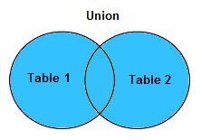

SELECT FirstName, LastName, 'Employee' AS Type

FROM employees

UNION

SELECT FirstName, LastName, 'Customer'

FROM customers

# JOINS

- A JOIN clause is used to combine rows from two or more tables, based on a related column between them.

## Types of Joins

- Inner Join
- Left Join
- Right Join
- FULL OUTER JOIN

## INNER JOIN

- Returns records that have matching values in both tables

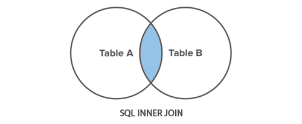

SELECT column_name(s) FROM table1 INNER JOIN table2 ON table1.column_name = table2.column_name;

## Chinook Database

### Option 1

SELECT

```
AlbumID,

title,

Name
```

FROM

```
Artist
```

INNER JOIN Albums ON albums.ArtistId = artists.ArtistId;

## Option 2

SELECT

```
         a.AlbumId,
         a.Title,
         ar.Name
```

FROM

```
albums a
```

INNER JOIN artists ar ON ar.ArtistId = a.ArtistId;

## Question

- Query trackid , name, composer and title from both tracks and albums

## Left Join

- The LEFT JOIN keyword returns all records from the left table (table1), and the matching records (if any) from the right table (table2)

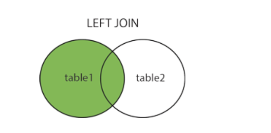

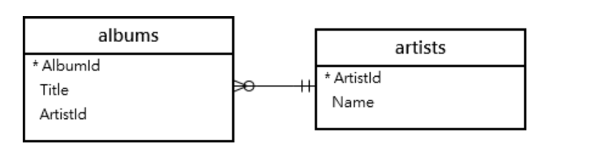

#### Question

- Find artists who do not have any albums by using the LEFT JOIN clause

SELECT artists.ArtistId, artists.Name, AlbumId

FROM artists

LEFT JOIN albums

ON albums.ArtistId = artists.ArtistId

ORDER BY AlbumId;

## Right Join

- The RIGHT JOIN keyword returns all records from the right table (table2), and the matching records from the left table (table1). The result is 0 records from the left side, if there is no match.

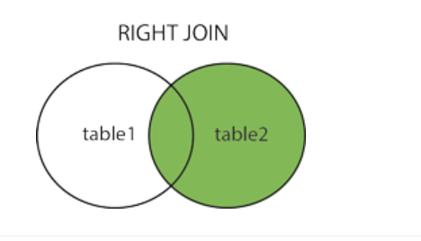

## Syntax

SELECT column_name(s)

FROM table1

RIGHT JOIN table2

ON table1.column_name = table2.column_name;

## Full Outer JOIN

- In SQL the FULL OUTER JOIN combines the results of both left and right outer joins and returns all (matched or unmatched) rows from the tables on both sides of the join clause.

## Full Outer Join Syntax

SELECT column_names(s)

FROM table1

FULL OUTER JOIN table2

ON table1.column_name=table2.column_name;

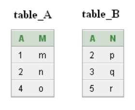

## Code

SELECT * FROM table_A

FULL OUTER JOIN table_B

ON table_A.A=table_B.A;

## Result

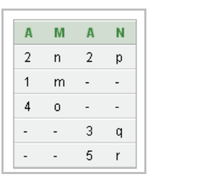

## Questions

- Find all the tracks that have a length of 5,000,000 milliseconds or more
- Find all the invoices whose total is between $1 and $10 dollars.
- Find all the tracks whose name starts with 'All'
- Find the albums with 12 or more tracks
- Show the number of orders placed by each customer (hint: this is found in the invoices table) and sort the result by the number of orders in descending order.
- Provide a query showing only the Employees who are Sales Agents.